# Labeling theory

CRIM 104

## Challenged previous explanations

- Off-shoot of older theories (particularly *symbolic interactionism*) that challenged previous definitions of deviance, noting that:
  - Earlier theories placed too much emphasis on the individual deviant and neglected to look at reaction to deviance
  - Illegality of some acts is not universal, which questions the notion that people who commit crimes are inexorably bad

## Focus on social reaction to deviance

- *Also known as the social reaction school:* Argues that what matters is how society reacts to deviant acts
- Developed into 2 perspectives which focus on:
  - The way in which people react to and label others
  - The effect of the label has on the labeled

## Social and intellectual context

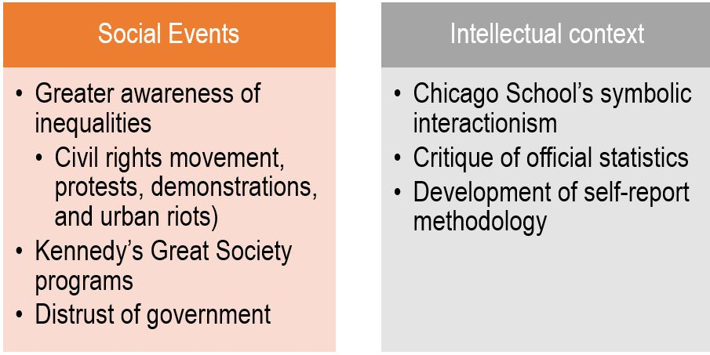

## Early labeling theory literature

- Frank Tannenbaum’s 1938 book Crime and the Community:
  - Criminal behavior is a product of conflict between a group and the community at large with opposing definitions of appropriate behavior
  - “Tag” attached to child caught in delinquent activity.
  - The “tag” may change the child’s self-image and causes people to react to the it, not the child.

## Definition of Crime (Becker)

- Different conceptions of what is right and proper
- Deviant act = criminal act only if law reflects the values of group that considers act deviant

## Labeling as a result of Societal reaction

- Label treated as the dependent variable
- Deviance is a product of others applying rules and laws to a presumed offender
- Types of deviant behaviour:
  - Falsely accused acts
  - Pure deviant acts
  - Conforming acts
  - Secret deviant acts

## Labeling as a cause of deviance

- Label as an independent variable treated as independent variable
- Two ways in which this may take place:
  - Labeling audience are more aware of individual and continue labeling him/her
  - Label internalized by the individual which leads to an acceptance of a deviant self-concept

## Lemert’s Secondary deviance

- Individual responses to society’s reaction vary
- Individual does not identify the initial act (primary deviance) as an important part of self-image.
- If original self-image is weak, labeled person may accept imposed label
- Secondary deviance results from process in which labeled person finally accepts the label

## Master Status and Retrospective Interpretation

- Master status: notion that certain traits take-over our perception of the identity of others
- Auxiliary status: notion that certain traits are ignored over an individual’s master status
- Once labeled a criminal, this becomes the individual’s master status
- Retrospective interpretation. The identities of individuals that get labelled are reconstructed to fit their “criminal” master status.

## Key terms

- Social reaction school
- Self-report surveys
- Tag
- Falsely accused acts
- Pure deviant acts
- Conforming acts
- Secret deviant acts
- Master status
- Auxiliary status
- Retrospective interpretation